# Tugas UTS Metode Numeris

## 3. Italia

```python
italia = get_data('italy', 'Italia')
```

### Active Cases

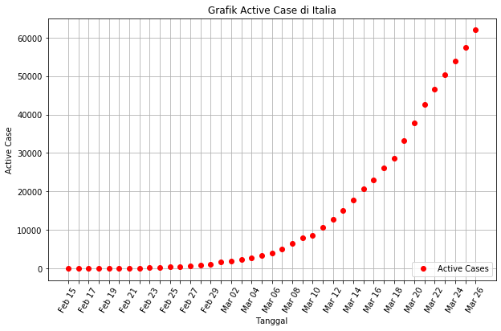

```python
plot_active_data(italia)
```

### Persamaan Regresi Berpangkat untuk Active Cases di Italia

```
=== Persamaan Regresi Berpangkat pada Active Cases di Italia ===
        Persamaan Regresi = y = 0.07374047915400343(x^(3.5971193027124744))
        Koefisien Korelasi = 0.9380529725666644
```

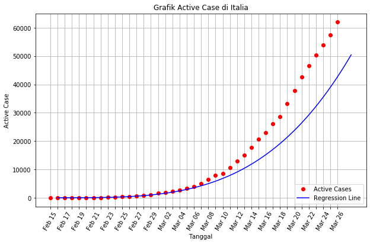

```python
italia_ac_p = regresi_aktif_berpangkat(italia)
```

### Persamaan Regresi Eksponensial untuk Active Cases di Italia

```
=== Persamaan Regresi Eksponensial pada Active Cases di Italia ===
        Persamaan Regresi = y = 7.1614e^(0.2585x)
        Koefisien Korelasi = 2.497884063420287
```

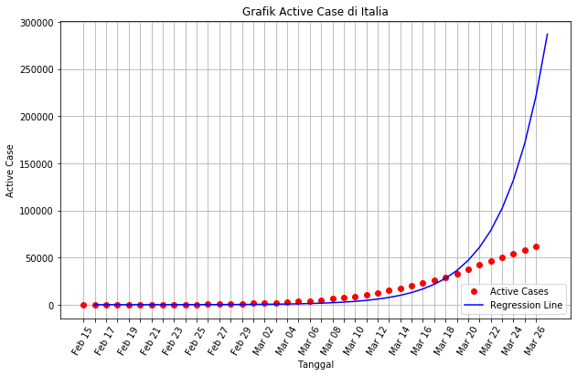

```python
italia_ac_e = regresi_aktif_eksponensial(italia)
```

Ternyata, pada regresi eksponensial didapatkan nilai koefisien korelasi yang tidak wajar. Oleh karena itu, saya coba bagi regresinya menjadi sebelum dan sesudah 5 maret, dimana pada 5 maret terjadi perubahan kecepatan pertumbuhan data

```
=== Persamaan Regresi Eksponensial pada Active Cases sebelum Mar 05 di Italia ===
            Persamaan Regresi = y = 1.0932e^(0.4443x)
            Koefisien Korelasi = 0.6471478633298677
```

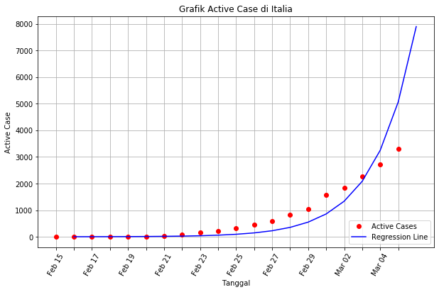

```python
italia_ac_be_e = regresi_aktif_eksponensial(italia, 'before', 'Mar 05')
```

```
=== Persamaan Regresi Eksponensial pada Active Cases setelah Mar 05 di Italia ===
            Persamaan Regresi = y = 300.4889e^(0.1358x)
            Koefisien Korelasi = 0.9636293049539592
```

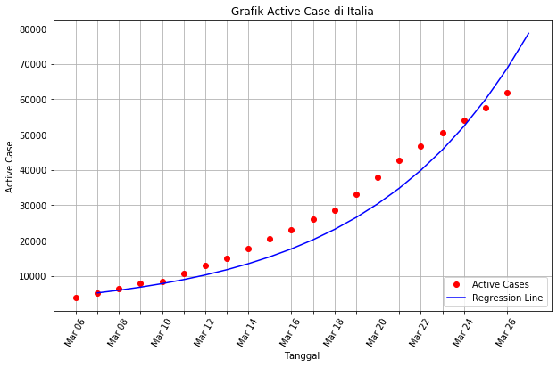

```python
italia_ac_af_e = regresi_aktif_eksponensial(italia, 'after', 'Mar 05')
```

### Persamaan Regresi Polinomial (orde 3) untuk Active Cases di Italia

```
=== Persamaan Regresi Polinomial pada Active Cases di Italia ===
        Persamaan Regresi = y = 2735.2743 + (-617.9025)x + (15.6041)x^2 + (0.8557)x^3
        Koefisien Korelasi = 0.9980581628362256
```

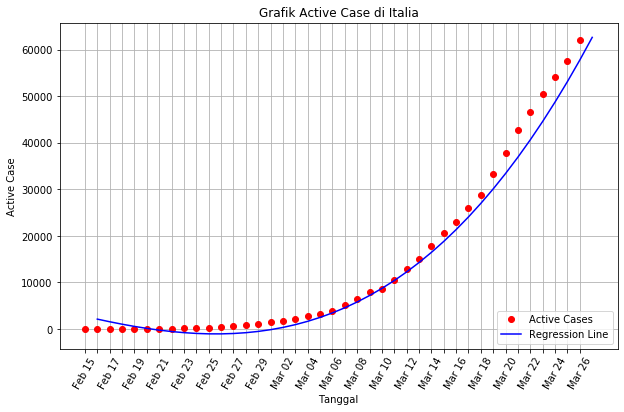

```python
italia_ac_po = regresi_aktif_polinomial(italia)
```

### Analisis kurva-kurva regresi pada Active Cases di Italia

```python
analisis('Active', italia_ac_p, italia_ac_be_e, italia_ac_po, italia_ac_p, italia_ac_af_e, italia_ac_po, '5 Maret')
```

```
=== Active Cases sebelum 5 Maret ===

        -Persamaan Regresi-
        Regresi Berpangkat: y = 0.07374047915400343(x^(3.5971193027124744))
        Regresi Eksponensial: y = 1.0932e^(0.4443x)
        Regresi Polinomial orde 3: y = 2735.2743 + (-617.9025)x + (15.6041)x^2 + (0.8557)x^3

        -Koefisien Korelasi-
        Regresi Berpangkat: 0.9381
        Regresi Eksponensial: 0.6471
        Regresi Polinomial orde 3: 0.9981

=== Active Cases sesudah 5 Maret hinga 26 Maret 2020 ===

        -Persamaan Regresi-
        Regresi Berpangkat: y = 0.07374047915400343(x^(3.5971193027124744))
        Regresi Eksponensial: y = 300.4889e^(0.1358x)
        Regresi Polinomial orde 3:`b y = 2735.2743 + (-617.9025)x + (15.6041)x^2 + (0.8557)x^3

        -Koefisien Korelasi-
        Regresi Berpangkat: 0.9381
        Regresi Eksponensial: 0.9636
        Regresi Polinomial orde 3: 0.9981
```

Dari data diatas, dapat kita simpulkan bahwa pada *active cases* di Italia, regresi polinomial orde 3 lah yang paling mewakili.

```python
kurva_negara['italia'] = {}
kurva_negara['italia']['ac'] = italia_ac_po
```

### Death Cases

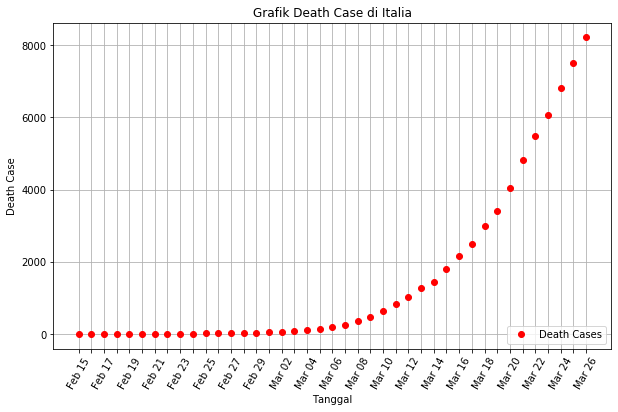

```python
plot_death_data(italia)
```

```python
print(italia['death_cases']['y'][:7])
print(italia['death_cases']['x'][6])
```

```
[0 0 0 0 0 0 1]
Feb 21
```

Terlihat bahwa sebelum tanggal 21 Februari belum terdapat *Death Case* sehingga data yang digunaka untuk mencari regresi adalah data setelah 20 Februari.

### Persamaan Regresi Berpangkat untuk *Death Cases* di Italia

```
=== Persamaan Regresi Berpangkat pada death Cases setelah Feb 20 di Italia ===
            Persamaan Regresi = y = 2.4622148290085102e-05(x^(5.288431479076284))
            Koefisien Korelasi = 0.9952431678974016
```

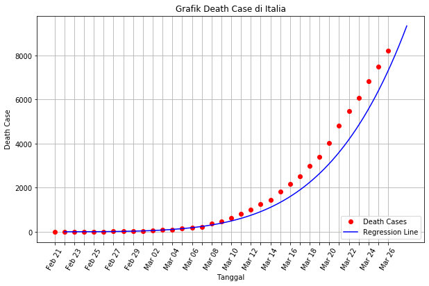

```python
italia_dc_p = regresi_death_berpangkat(italia, 'after', 'Feb 20')
```

### Persamaan Regresi Eksponensial untuk *Death Cases* di Italia

```
=== Persamaan Regresi Eksponensial pada Death Cases setelah Feb 20 di Italia ===
            Persamaan Regresi = y = 0.6175e^(0.2544x)
            Koefisien Korelasi = 0.6541087093357791
```

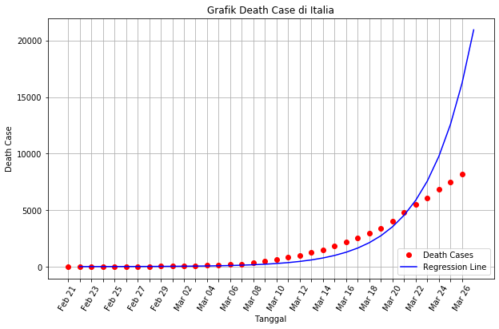

```python
italia_dc_e = regresi_death_eksponensial(italia, 'after', 'Feb 20')
```

### Persamaan Regresi Polinomial (orde 3) untuk *Death Cases* di Italia

```
=== Persamaan Regresi Polinomial pada Death Cases setelah Feb 21 di Italia ===
            Persamaan Regresi = y = 1811.5441 + (-208.8578)x + (2.9339)x^2 + (0.1427)x^3
            Koefisien Korelasi = 0.9966978029746382
```

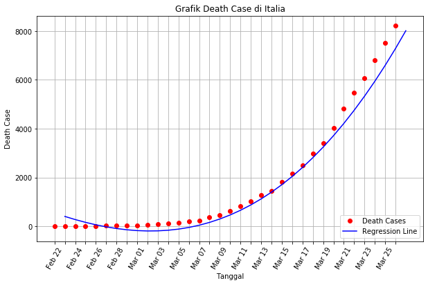

```python
italia_dc_po = regresi_death_polinomial(italia, 'after', 'Feb 21')
```

### Analisis kurva-kurva regresi pada *Death Cases* di Italia

```python
analisis('Death', italia_dc_p, italia_dc_e, italia_dc_po)
```

```
=== Death Cases hingga 26 Maret 2020 ===

        -Persamaan Regresi-
        Regresi Berpangkat: y = 2.4622148290085102e-05(x^(5.288431479076284))
        Regresi Eksponensial: y = 0.6175e^(0.2544x)
        Regresi Polinomial orde 3: y = 1811.5441 + (-208.8578)x + (2.9339)x^2 + (0.1427)x^3

        -Koefisien Korelasi-
        Regresi Berpangkat: 0.9952
        Regresi Eksponensial: 0.6541
        Regresi Polinomial orde 3: 0.9967
```

Dapat kita lihat berdasarkan data di atas, bahwasanya kurva regresi polinomial orde 3 merupakan kurva yang paling cocok untuk mewakili data *Death Cases* di Italia.

```python
kurva_negara['italia']['dc'] = italia_dc_po
```

## 4. Iran

```python
iran = get_data('iran', 'Iran')
```

### Active Cases

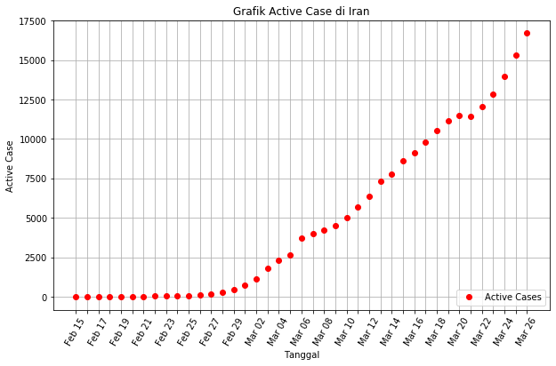

```python
plot_active_data(iran)
```

### Persamaan Regresi Berpangkat pada *Active Cases* di Iran

```
=== Persamaan Regresi Berpangkat pada Active Cases di Iran ===
        Persamaan Regresi = y = 0.026836376306122307(x^(3.6320094590812335))
        Koefisien Korelasi = 0.9606926044856466
```

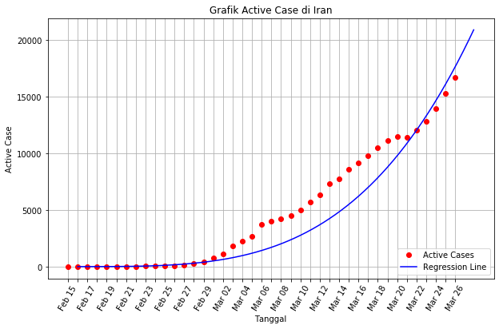

```python
iran_ac_p = regresi_aktif_berpangkat(iran)
```

### Persamaan Regresi Eksponensial pada *Active Cases* di Iran

```
=== Persamaan Regresi Eksponensial pada Active Cases di Iran ===
        Persamaan Regresi = y = 3.0382e^(0.2558x)
        Koefisien Korelasi = 4.057115204215351
```

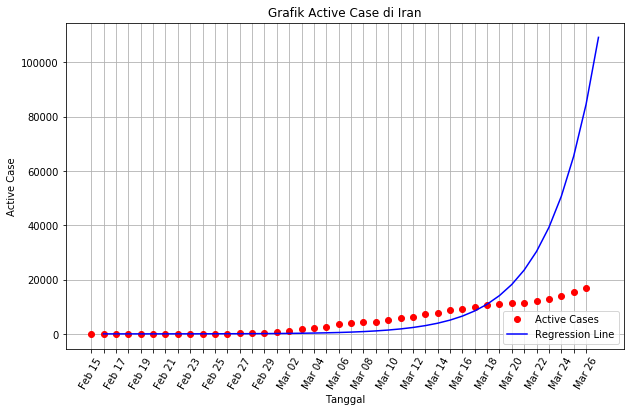

```python
iran_ac_e = regresi_aktif_eksponensial(iran)
```

Karena didapatkan koefisien korelasi yang tidak wajar, yaitu bernilai dari satu, maka regresi saya bagi menjadi sebelum dan sesudah 29 Februari, yaitu tanggal dimana terjadi perubahan kecepatan pertumbuhan data.

```
=== Persamaan Regresi Eksponensial pada Active Cases sebelum Feb 29 di Iran ===
            Persamaan Regresi = y = 0.2690e^(0.4939x)
            Koefisien Korelasi = 0.9981538207368842
```

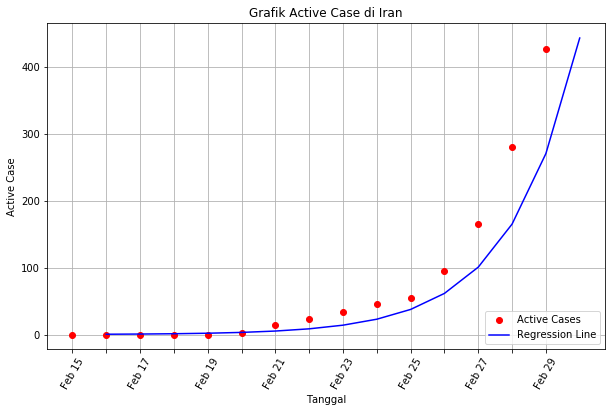

```python
iran_ac_be_e = regresi_aktif_eksponensial(iran, 'before', 'Feb 29')
```

```
=== Persamaan Regresi Eksponensial pada Active Cases setelah Feb 29 di Iran ===
            Persamaan Regresi = y = 338.6379e^(0.1010x)
            Koefisien Korelasi = 0.9187137433762697
```

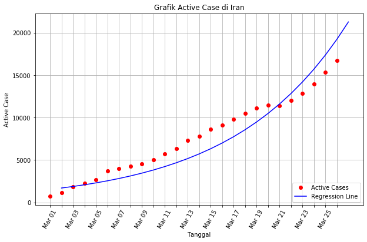

```python
iran_ac_af_e = regresi_aktif_eksponensial(iran, 'after', 'Feb 29')
```

### Persamaan Regresi Polinomial (orde 3) pada *Active Cases* di Iran

```
=== Persamaan Regresi Polinomial pada Active Cases di Iran ===
        Persamaan Regresi = y = -1192.6239 + (205.2842)x + (-5.8355)x^2 + (0.2868)x^3
        Koefisien Korelasi = 0.9898880848757589
```

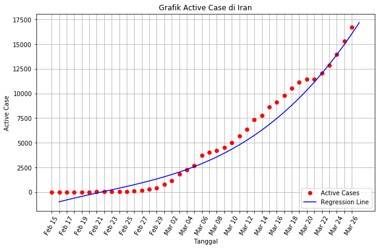

```python
iran_ac_po = regresi_aktif_polinomial(iran)
```

### Analisis kurva-kurva regresi pada *Active Cases* di Iran

```python
analisis('Active', iran_ac_p, iran_ac_be_e, iran_ac_po, iran_ac_p, iran_ac_af_e, iran_ac_po, '29 Februari')
```

```
=== Active Cases sebelum 29 Februari ===

        -Persamaan Regresi-
        Regresi Berpangkat: y = 0.026836376306122307(x^(3.6320094590812335))
        Regresi Eksponensial: y = 0.2690e^(0.4939x)
        Regresi Polinomial orde 3: y = -1192.6239 + (205.2842)x + (-5.8355)x^2 + (0.2868)x^3

        -Koefisien Korelasi-
        Regresi Berpangkat: 0.9607
        Regresi Eksponensial: 0.9982
        Regresi Polinomial orde 3: 0.9899

=== Active Cases sesudah 29 Februari hinga 26 Maret 2020 ===

        -Persamaan Regresi-
        Regresi Berpangkat: y = 0.026836376306122307(x^(3.6320094590812335))
        Regresi Eksponensial: y = 338.6379e^(0.1010x)
        Regresi Polinomial orde 3:`b y = -1192.6239 + (205.2842)x + (-5.8355)x^2 + (0.2868)x^3

        -Koefisien Korelasi-
        Regresi Berpangkat: 0.9607
        Regresi Eksponensial: 0.9187
        Regresi Polinomial orde 3: 0.9899
```

Dari data di atas, kita dapat mengambil kesimpulan bahwa:

1. Regresi Eksponensial mewakili data *Active Cases* di Iran, namun hanya sampai tanggal 29 Februari
2. Regresi Polinomial orde 3 mewakili data *Active Cases* di Iran setelah tanggal 29 Februari, bisa juga dianggap regresi polinomial orde 3 mewakili data secara keseluruhan.

```python
kurva_negara['iran'] = {}
kurva_negara['iran']['ac'] = iran_ac_po
```

### Death Cases

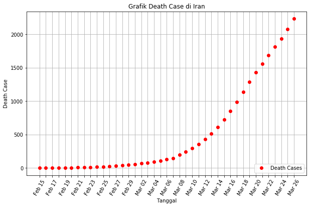

```python
plot_death_data(iran)
```

```python
print(iran['death_cases']['y'][0:5])
print(iran['death_cases']['x'][4])
```

```
[0 0 0 0 2]
Feb 19
```

Terlihat bahwa sebelum tanggal 19 Feb belum terdapat *Death Case* di Iran. Oleh karena itu, data yang digunakan untuk mencari regresi hanya data setelah 18 Februari.

```
=== Persamaan Regresi Berpangkat pada Active Cases setelah Feb 18 di Iran ===
            Persamaan Regresi = y = 0.001877740416396793(x^(4.4932988427926315))
            Koefisien Korelasi = 0.18028872696743448
```

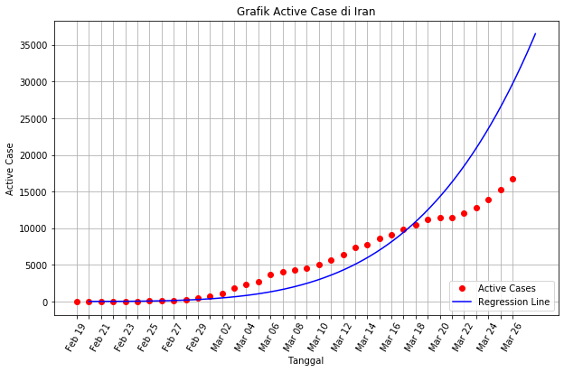

```python
iran_dc_p = regresi_aktif_berpangkat(iran, 'after', 'Feb 18')
```

### Persamaan Regresi Eksponensial untuk *Death Cases* di Iran

```
=== Persamaan Regresi Eksponensial pada Death Cases setelah Feb 18 di Iran ===
            Persamaan Regresi = y = 1.7598e^(0.1926x)
            Koefisien Korelasi = 0.5552090119790247
```

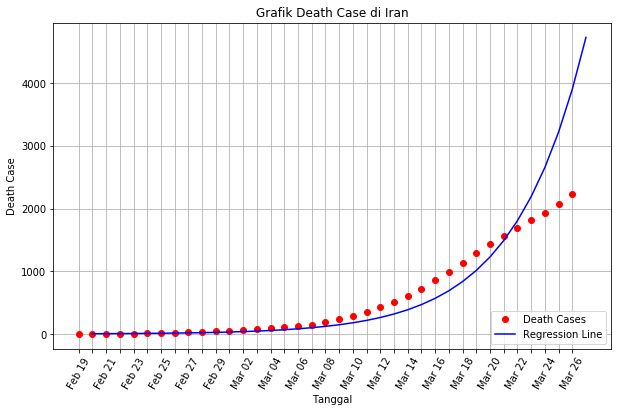

```python
iran_dc_e = regresi_death_eksponensial(iran, 'after', 'Feb 18')
```

### Persamaan Regresi Polinomial (orde 3) untuk *Death Cases* di Iran

```
=== Persamaan Regresi Polinomial pada Death Cases setelah Feb 18 di Iran ===
            Persamaan Regresi = y = 445.8963 + (-76.6129)x + (2.9388)x^2 + (-0.0000)x^3
            Koefisien Korelasi = 0.9960113779954755
```

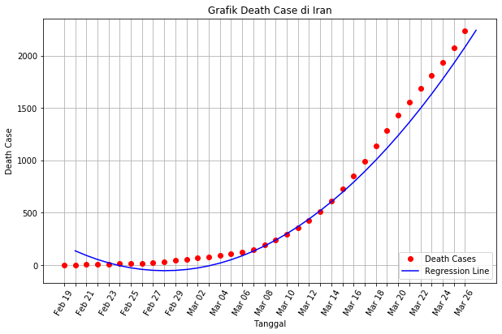

```python
iran_dc_po = regresi_death_polinomial(iran, 'after', 'Feb 18')
```

### Analisis kurva-kurva regresi untuk *Death Cases* di Iran

```python
analisis('Death', iran_dc_p, iran_dc_e, iran_dc_po)
```

```
=== Death Cases hingga 26 Maret 2020 ===

        -Persamaan Regresi-
        Regresi Berpangkat: y = 0.001877740416396793(x^(4.4932988427926315))
        Regresi Eksponensial: y = 1.7598e^(0.1926x)
        Regresi Polinomial orde 3: y = 445.8963 + (-76.6129)x + (2.9388)x^2 + (-0.0000)x^3

        -Koefisien Korelasi-
        Regresi Berpangkat: 0.1803
        Regresi Eksponensial: 0.5552
        Regresi Polinomial orde 3: 0.9960
```

Dari data di atas, dapat dilihat bahwa regresi polinomial orde 3 lah yang paling mewakili data *Death Cases* di Iran.

```python
kurva_negara['iran']['dc'] = iran_dc_po
```

## 5. Spanyol

```python
spanyol = get_data('spain', 'Spanyol')
```

### Active Cases

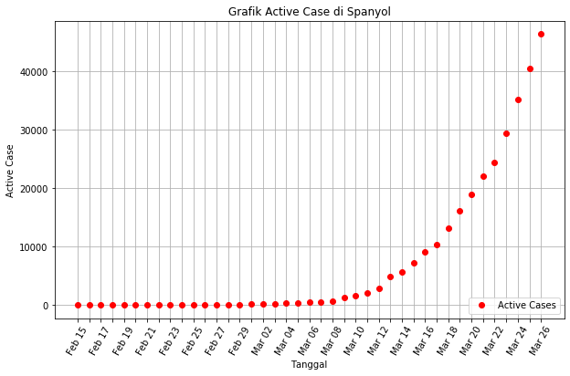

```python
plot_active_data(spanyol)
```

```python
print(spanyol['active_cases']['y'][0:10])
print(spanyol['active_cases']['x'][9])
```

```
[0 0 0 0 0 0 0 0 0 1]
Feb 24
```

Sebelum tanggal 24 Februari, belum ada Active Cases di Spanyol. Sehingga, saya hanya menggunakan data setelah 23 Februari untuk membentuk regresinya.

### Persamaan Regresi Berpangkat untuk *Active Cases* di Spanyol

```
=== Persamaan Regresi Berpangkat pada Active Cases setelah Feb 23 di Spanyol ===
            Persamaan Regresi = y = 2.0358411973331635e-07(x^(7.0868801138312465))
            Koefisien Korelasi = 0.9877086581770133
```

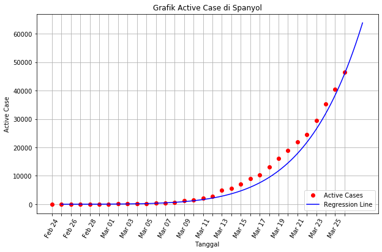

```python
spanyol_ac_p = regresi_aktif_berpangkat(spanyol, 'after', 'Feb 23')
```

### Persamaan Regresi Eksponensial untuk *Active Cases* di Spanyol

```
=== Persamaan Regresi Eksponensial pada Active Cases setelah Feb 23 di Spanyol ===
            Persamaan Regresi = y = 0.4792e^(0.3038x)
            Koefisien Korelasi = 0.9312003720632857
```

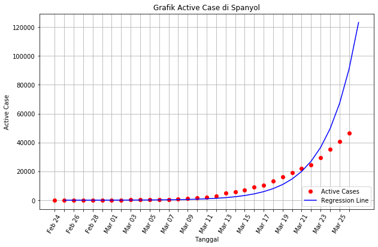

```python
spanyol_ac_e = regresi_aktif_eksponensial(spanyol, 'after', 'Feb 23')
```

### Persamaan Regresi Polinomial (orde 3) untuk *Active Cases* di Spanyol

```
=== Persamaan Regresi Polinomial pada Active Cases setelah Feb 23 di Spanyol ===
            Persamaan Regresi = y = 22090.8846 + (-2437.6071)x + (53.5164)x^2 + (0.4274)x^3
            Koefisien Korelasi = 0.9891220511517428
```

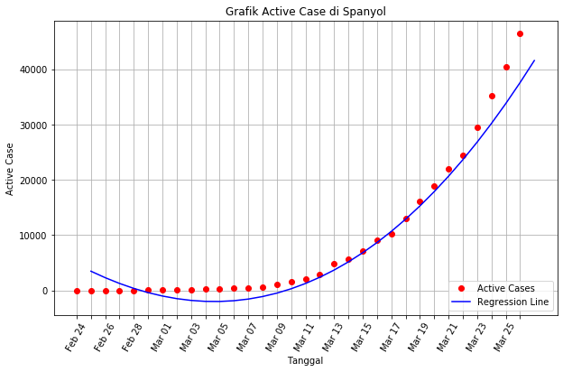

```python
spanyol_ac_po = regresi_aktif_polinomial(spanyol, 'after', 'Feb 23')
```

### Analisis kurva-kurva regresi pada *Active Cases* di Spanyol

```python
analisis('Active', spanyol_ac_p, spanyol_ac_e, spanyol_ac_po)
```

```
=== Active Cases hingga 26 Maret 2020 ===

        -Persamaan Regresi-
        Regresi Berpangkat: y = 2.0358411973331635e-07(x^(7.0868801138312465))
        Regresi Eksponensial: y = 0.4792e^(0.3038x)
        Regresi Polinomial orde 3: y = 22090.8846 + (-2437.6071)x + (53.5164)x^2 + (0.4274)x^3

        -Koefisien Korelasi-
        Regresi Berpangkat: 0.9877
        Regresi Eksponensial: 0.9312
        Regresi Polinomial orde 3: 0.9891
```

Dari data yang didapatkan, dapat disimpulkan bahwa persamaan regresi polinomial orde 3 lah yang mewakili data Active Cases di Spanyol.

```python
kurva_negara['spanyol'] = {}
kurva_negara['spanyol']['ac'] = spanyol_ac_po
```

### Death Cases

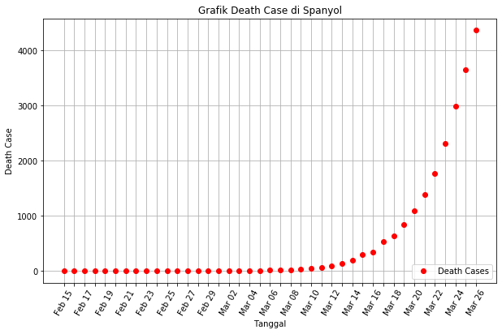

```python
plot_death_data(spanyol)
```

```python
print(spanyol['death_cases']['y'][0:18])
print(spanyol['death_cases']['x'][17])
```

```
[0 0 0 0 0 0 0 0 0 0 0 0 0 0 0 0 0 1]
Mar 03
```

Sebelum tanggal 3 Maret, Death Case di Spanyol adalah 0. Sehingga, saya menggunakan data setelah 2 Maret untuk mencari regresinya.

### Persamaan Regresi Berpangkat untuk *Death Cases* di Spanyol

```
=== Persamaan Regresi Berpangkat pada death Cases setelah Mar 02 di Spanyol ===
            Persamaan Regresi = y = 2.9212502288381056e-13(x^(10.08724253786933))
            Koefisien Korelasi = 0.9776119201759231
```

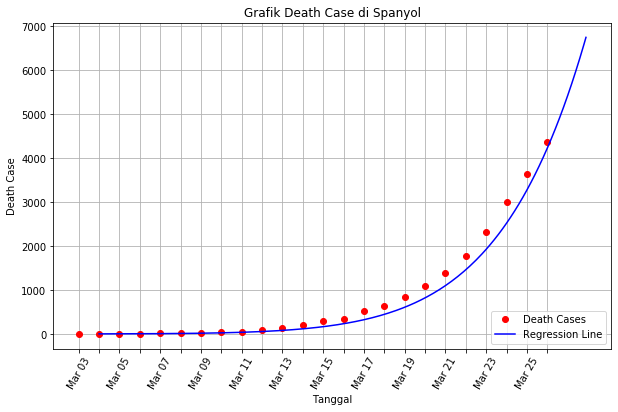

```python
spanyol_dc_p = regresi_death_berpangkat(spanyol, 'after', 'Mar 02')
```

### Persamaan Regresi Eksponensial untuk *Death Cases* di Spanyol

```
=== Persamaan Regresi Eksponensial pada Death Cases setelah Mar 02 di Spanyol ===
            Persamaan Regresi = y = 0.0045e^(0.3522x)
            Koefisien Korelasi = 0.6035872321598443
```

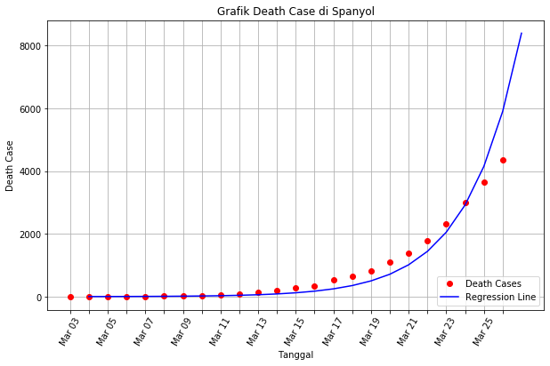

```python
spanyol_dc_e = regresi_death_eksponensial(spanyol, 'after', 'Mar 02')
```

### Persamaan Regresi Polinomial (orde 3) untuk *Death Cases* di Spanyol

```
=== Persamaan Regresi Polinomial pada Death Cases setelah Mar 02 di Spanyol ===
            Persamaan Regresi = y = 8589.5360 + (-720.6674)x + (14.7438)x^2 + (-0.0000)x^3
            Koefisien Korelasi = 0.9797319455985405
```

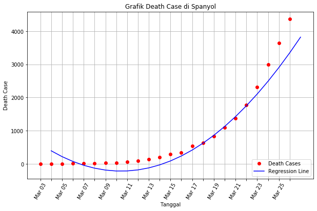

```python
spanyol_dc_po = regresi_death_polinomial(spanyol, 'after', 'Mar 02')
```

### Analisis kurva-kurva regresi pada *Death Cases* di Spanyol

```python
analisis('Death', spanyol_dc_p, spanyol_dc_e, spanyol_dc_po)
```

```
=== Death Cases hingga 26 Maret 2020 ===

        -Persamaan Regresi-
        Regresi Berpangkat: y = 2.9212502288381056e-13(x^(10.08724253786933))
        Regresi Eksponensial: y = 0.0045e^(0.3522x)
        Regresi Polinomial orde 3: y = 8589.5360 + (-720.6674)x + (14.7438)x^2 + (-0.0000)x^3

        -Koefisien Korelasi-
        Regresi Berpangkat: 0.9776
        Regresi Eksponensial: 0.6036
        Regresi Polinomial orde 3: 0.9797
```

Dari data koefisien korelasi masing-masing persamaan di atas, dapat kita disimpulkan bahwa kurva regresi polinomial orde 3 merupakan kurva regresi yang paling mewakili data *Death Cases* di Spanyol.

```python
kurva_negara['spanyol']['dc'] = spanyol_dc_po
```

## 6. Jerman

```python
jerman = get_data('germany', 'Jerman')
```

### Active Cases

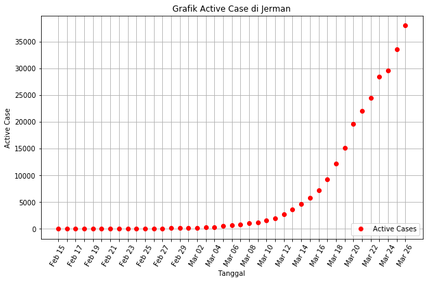

```python
plot_active_data(jerman)
```

```python
print(jerman['active_cases']['y'][:20])
print(jerman['active_cases']['x'][10])
```

```
[ 13  13   9   7   7   3   2   2   2   2   3  11  32  58  63 114 149 187
 246 528]
Feb 25
```

Terlihat bahwa data mengalami penurunan hingga 25 Februari, namun kemudian naik kembali. Oleh karena itu, regresi, kami bagi menjadi dua bagian, sebelum 25 Februari dan setelah 25 Februari.

### Persamaan Regresi Berpangkat untuk *Active Cases* di Jerman

```
=== Persamaan Regresi Berpangkat pada Active Cases sebelum Feb 25 di Jerman ===
            Persamaan Regresi = y = 19.475315256463215(x^(-0.9411255263167502))
            Koefisien Korelasi = 0.8011763776157965
```

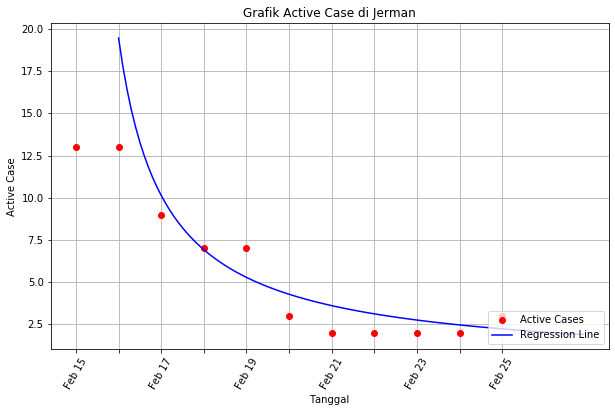

```python
jerman_ac_be_p = regresi_aktif_berpangkat(jerman, 'before', 'Feb 25')
```

```
=== Persamaan Regresi Berpangkat pada Active Cases setelah Feb 25 di Jerman ===
            Persamaan Regresi = y = 1.5922372787788378e-06(x^(6.4760009131577325))
            Koefisien Korelasi = 0.9877413330274332
```

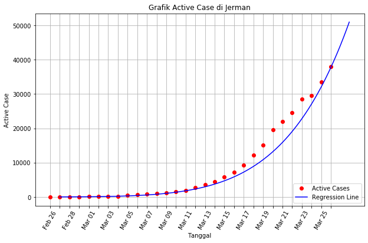

```python
jerman_ac_af_p = regresi_aktif_berpangkat(jerman, 'after', 'Feb 25')
```

### Persamaan Regresi Eksponensial untuk *Active Cases* di Jerman

```
=== Persamaan Regresi Eksponensial pada Active Cases sebelum Feb 25 di Jerman ===
            Persamaan Regresi = y = 15.3502e^(-0.2099x)
            Koefisien Korelasi = 0.9474278036072419
```

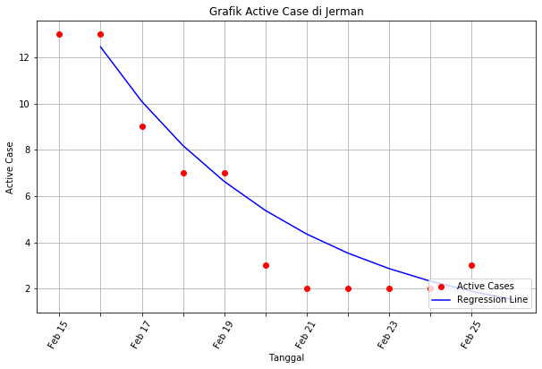

```python
jerman_ac_be_e = regresi_aktif_eksponensial(jerman, 'before', 'Feb 25')
```

```
=== Persamaan Regresi Eksponensial pada Active Cases setelah Feb 25 di Jerman ===
            Persamaan Regresi = y = 1.6928e^(0.2627x)
            Koefisien Korelasi = 0.4849538841563778
```

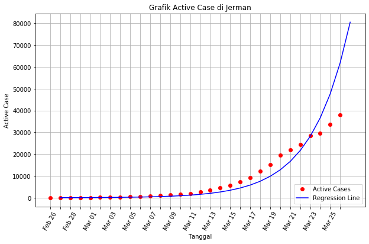

```python
jerman_ac_af_e = regresi_aktif_eksponensial(jerman, 'after', 'Feb 25')
```

### Persamaan Regresi Polinomial (orde 3) untuk *Active Cases* di Jerman

```
=== Persamaan Regresi Polinomial pada Active Cases sebelum Feb 25 di Jerman ===
            Persamaan Regresi = y = 15.2576 + (-1.4959)x + (-0.1876)x^2 + (0.0204)x^3
            Koefisien Korelasi = 0.9832051697107491
```

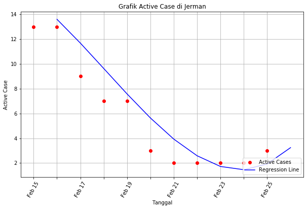

```python
jerman_ac_be_po = regresi_aktif_polinomial(jerman, 'before', 'Feb 25')
```

```
=== Persamaan Regresi Polinomial pada Active Cases setelah Feb 25 di Jerman ===
            Persamaan Regresi = y = 22083.6144 + (-2264.4532)x + (46.6215)x^2 + (0.4281)x^3
            Koefisien Korelasi = 0.9939173203426981
```

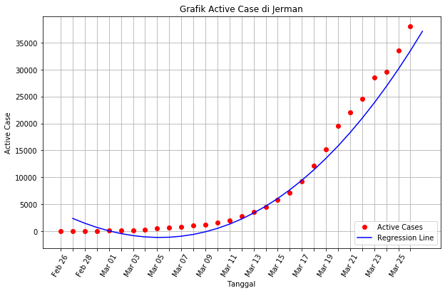

```python
jerman_ac_af_po = regresi_aktif_polinomial(jerman, 'after', 'Feb 25')
```

### Analisis kurva-kurva regresi pada *Active Cases* di Jerman

```python
analisis('Active', jerman_ac_be_p, jerman_ac_be_e, jerman_ac_be_po, jerman_ac_af_p, jerman_ac_af_e, jerman_ac_af_po, '25 Februari')
```

```
=== Active Cases sebelum 25 Februari ===

        -Persamaan Regresi-
        Regresi Berpangkat: y = 19.475315256463215(x^(-0.9411255263167502))
        Regresi Eksponensial: y = 15.3502e^(-0.2099x)
        Regresi Polinomial orde 3: y = 15.2576 + (-1.4959)x + (-0.1876)x^2 + (0.0204)x^3

        -Koefisien Korelasi-
        Regresi Berpangkat: 0.8012
        Regresi Eksponensial: 0.9474
        Regresi Polinomial orde 3: 0.9832

=== Active Cases sesudah 25 Februari hinga 26 Maret 2020 ===

        -Persamaan Regresi-
        Regresi Berpangkat: y = 1.5922372787788378e-06(x^(6.4760009131577325))
        Regresi Eksponensial: y = 1.6928e^(0.2627x)
        Regresi Polinomial orde 3:`b y = 22083.6144 + (-2264.4532)x + (46.6215)x^2 + (0.4281)x^3

        -Koefisien Korelasi-
        Regresi Berpangkat: 0.9877
        Regresi Eksponensial: 0.4850
        Regresi Polinomial orde 3: 0.9939
```

Dari data di atas, terlihat bahwa kurva polinomial orde 3 lah yang mewakili Active Cases di Jerman.

```python
kurva_negara['jerman'] = {}
kurva_negara['jerman']['ac'] = jerman_ac_af_po
```

### Death Cases

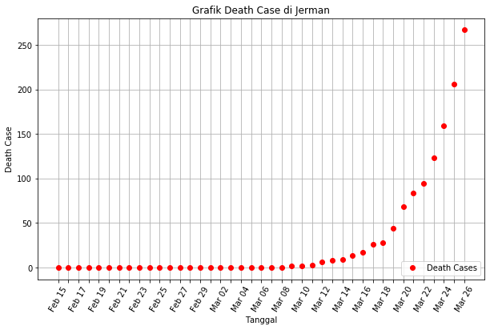

```python
plot_death_data(jerman)
```

```python
print(jerman['death_cases']['y'][0:24])
print(jerman['death_cases']['x'][23])
```

```
[0 0 0 0 0 0 0 0 0 0 0 0 0 0 0 0 0 0 0 0 0 0 0 2]
Mar 09
```

Terlihat bahwa sebelum tanggal 9 Maret, belum ada *Death Case* di Jerman, sehingga untuk regresi hanya saya gunakan data setelah tanggal 8 Maret.

### Persamaan Regresi Berpangkat untuk *Death Cases* di Jerman

```
=== Persamaan Regresi Berpangkat pada death Cases setelah Mar 08 di Jerman ===
            Persamaan Regresi = y = 1.4576047389840633e-13(x^(9.456378785399764))
            Koefisien Korelasi = 0.9986108546776234
```

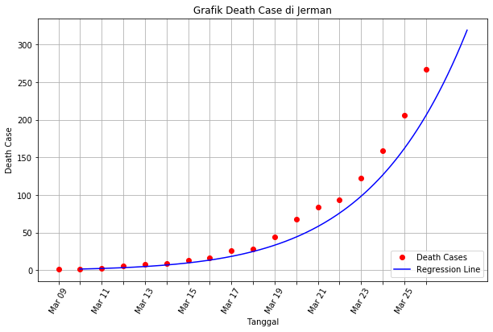

```python
jerman_dc_p = regresi_death_berpangkat(jerman, 'after', 'Mar 08')
```

### Persamaan Regresi Eksponensial untuk *Death Cases* di Jerman

```
=== Persamaan Regresi Eksponensial pada Death Cases setelah Mar 08 di Jerman ===
            Persamaan Regresi = y = 0.0017e^(0.2957x)
            Koefisien Korelasi = 0.9813612525790941
```

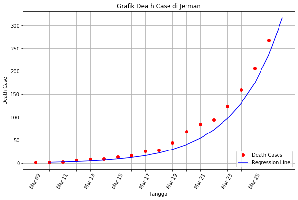

```python
jerman_dc_e = regresi_death_eksponensial(jerman, 'after', 'Mar 08')
```

### Persamaan Regresi Polinomial (orde 3) untuk *Death Cases* di Jerman

```
=== Persamaan Regresi Polinomial pada Death Cases setelah Mar 08 di Jerman ===
            Persamaan Regresi = y = 1092.6520 + (-78.5479)x + (1.4075)x^2 + (-0.0000)x^3
            Koefisien Korelasi = 0.9879194785551578
```

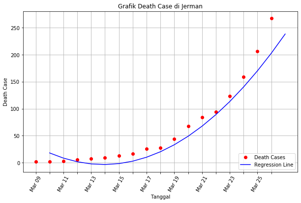

```python
jerman_dc_po = regresi_death_polinomial(jerman, 'after', 'Mar 08')
```

### Analisis kurva-kurva regresi untuk *Death Cases* di Jerman

```python
analisis('Death', jerman_dc_p, jerman_dc_e, jerman_dc_po)
```

```
=== Death Cases hingga 26 Maret 2020 ===

        -Persamaan Regresi-
        Regresi Berpangkat: y = 1.4576047389840633e-13(x^(9.456378785399764))
        Regresi Eksponensial: y = 0.0017e^(0.2957x)
        Regresi Polinomial orde 3: y = 1092.6520 + (-78.5479)x + (1.4075)x^2 + (-0.0000)x^3

        -Koefisien Korelasi-
        Regresi Berpangkat: 0.9986
        Regresi Eksponensial: 0.9814
        Regresi Polinomial orde 3: 0.9879
```

```python
kurva_negara['jerman']['dc'] = jerman_dc_po
```

## 7. Australia

```python
australia = get_data('australia', 'Australia')
```

### Active Cases

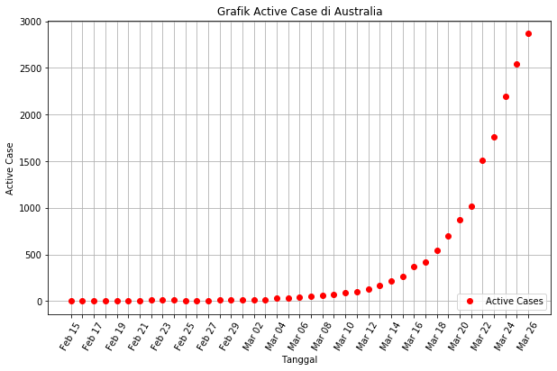

```python
plot_active_data(australia)
```

Untuk hasil regresi yang akurat, saya akan membagi regresi menjadi sebelum dan sesudah tanggal 03 Maret.

### Persamaan Regresi Berpangkat untuk *Active Cases* di Australia

```
=== Persamaan Regresi Berpangkat pada Active Cases sebelum Mar 03 di Australia ===
            Persamaan Regresi = y = 3.5198303379089997(x^(0.4205656885448712))
            Koefisien Korelasi = 0.7839139511462498
```

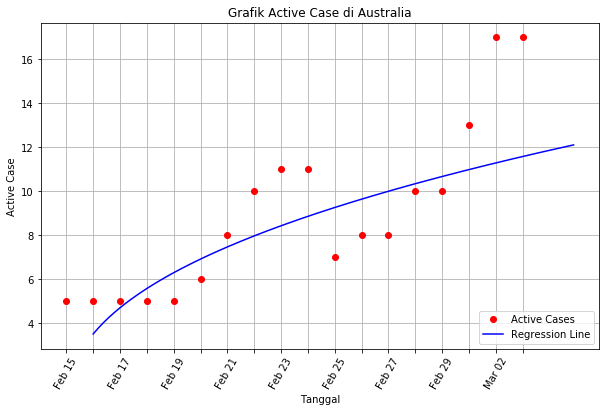

```python
australia_ac_be_p = regresi_aktif_berpangkat(australia, 'before', 'Mar 03')
```

```
=== Persamaan Regresi Berpangkat pada Active Cases setelah Mar 03 di Australia ===
            Persamaan Regresi = y = 1.5799481378297832e-07(x^(6.31010767698038))
            Koefisien Korelasi = 0.9727420188765891
```

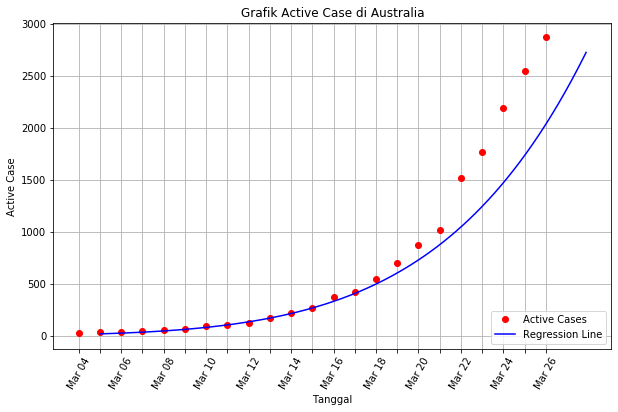

```python
australia_ac_af_p = regresi_aktif_berpangkat(australia, 'after', 'Mar 03')
```

### Persamaan Regresi Eksponensial untuk *Active Cases* di Australia

```
=== Persamaan Regresi Eksponensial pada Active Cases sebelum Mar 03 di Australia ===
            Persamaan Regresi = y = 4.2970e^(0.0685x)
            Koefisien Korelasi = 0.8725545093707052
```

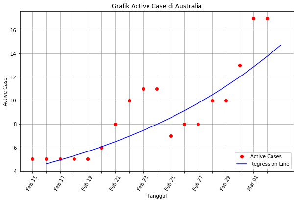

```python
australia_ac_be_e = regresi_aktif_eksponensial(australia, 'before', 'Mar 03')
```

```
=== Persamaan Regresi Eksponensial pada Active Cases setelah Mar 03 di Australia ===
            Persamaan Regresi = y = 0.3838e^(0.2199x)
            Koefisien Korelasi = 0.9948595949184545
```

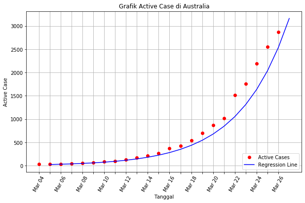

```python
australia_ac_af_e = regresi_aktif_eksponensial(australia, 'after', 'Mar 03')
```

### Persamaan Regresi Polinomial (orde 3) untuk *Active Cases* di Australia

```
=== Persamaan Regresi Polinomial pada Active Cases sebelum Mar 03 di Australia ===
            Persamaan Regresi = y = 1.9183 + (1.8038)x + (-0.1980)x^2 + (0.0081)x^3
            Koefisien Korelasi = 0.9046147643037508
```

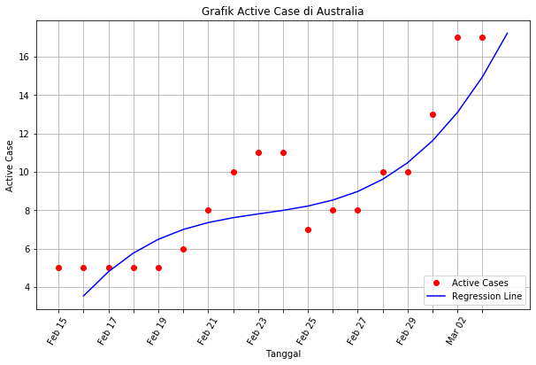

```python
australia_ac_be_po = regresi_aktif_polinomial(australia, 'before', 'Mar 03')
```

```
=== Persamaan Regresi Polinomial pada Active Cases setelah Mar 03 di Australia ===
            Persamaan Regresi = y = 6043.6010 + (-498.3741)x + (10.1770)x^2 + (-0.0000)x^3
            Koefisien Korelasi = 0.98864216665422
```

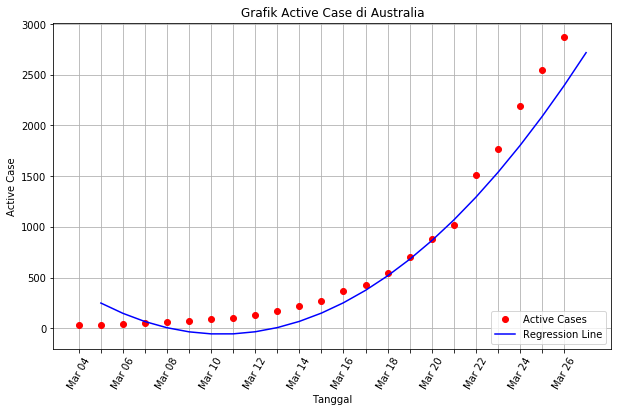

```python
australia_ac_af_po = regresi_aktif_polinomial(australia, 'after', 'Mar 03')
```

### Analisis kurva-kurva regresi pada *Active Cases* di Australia

```python
analisis('Active', australia_ac_be_p, australia_ac_be_e, australia_ac_be_po, australia_ac_af_p, australia_ac_af_e, australia_ac_af_po, '3 Maret')
```

```
=== Active Cases sebelum 3 Maret ===

        -Persamaan Regresi-
        Regresi Berpangkat: y = 3.5198303379089997(x^(0.4205656885448712))
        Regresi Eksponensial: y = 4.2970e^(0.0685x)
        Regresi Polinomial orde 3: y = 1.9183 + (1.8038)x + (-0.1980)x^2 + (0.0081)x^3

        -Koefisien Korelasi-
        Regresi Berpangkat: 0.7839
        Regresi Eksponensial: 0.8726
        Regresi Polinomial orde 3: 0.9046

=== Active Cases sesudah 3 Maret hinga 26 Maret 2020 ===

        -Persamaan Regresi-
        Regresi Berpangkat: y = 1.5799481378297832e-07(x^(6.31010767698038))
        Regresi Eksponensial: y = 0.3838e^(0.2199x)
        Regresi Polinomial orde 3:`b y = 6043.6010 + (-498.3741)x + (10.1770)x^2 + (-0.0000)x^3

        -Koefisien Korelasi-
        Regresi Berpangkat: 0.9727
        Regresi Eksponensial: 0.9949
        Regresi Polinomial orde 3: 0.9886
```

Dari data diatas, dapat diambil kesimpulan berupa:

1. Sebelum 03 Maret, data diwakili oleh kurva regresi polinomial orde 3
2. Setelah 03 Maret, data diwakili oleh kurva regresi eksponensial.

```python
kurva_negara['australia'] = {}
kurva_negara['australia']['ac'] = australia_ac_af_e
```

### Death Cases

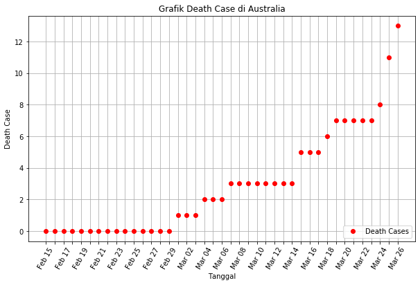

```python
plot_death_data(australia)
```

```python
print(australia['death_cases']['y'][:16])
print(australia['death_cases']['x'][15])
```

```
[0 0 0 0 0 0 0 0 0 0 0 0 0 0 0 1]
Mar 01
```

Terlihat bahwa sebelum tanggal 01 Maret belum terdapat *Death Case* di Australia, sehingga data yang akan saya gunakan adalh data setelah 29 Februari.

### Persamaan Regresi Berpangkat untuk *Death Cases* di Australia

```
=== Persamaan Regresi Berpangkat pada death Cases setelah Feb 29 di Australia ===
            Persamaan Regresi = y = 0.0012146203508963862(x^(2.4241807762991976))
            Koefisien Korelasi = 0.9549834138405254
```

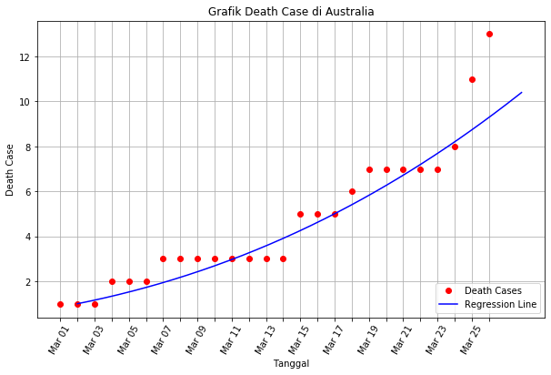

```python
australia_dc_p = regresi_death_berpangkat(australia, 'after', 'Feb 29')
```

### Persamaan Regresi Eksponensial untuk *Death Cases* di Australia

```
=== Persamaan Regresi Eksponensial pada Death Cases setelah Feb 29 di Australia ===
            Persamaan Regresi = y = 0.2934e^(0.0893x)
            Koefisien Korelasi = 0.9685497805650918
```

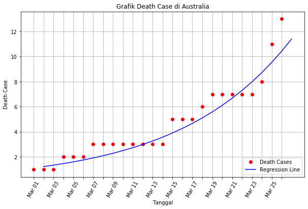

```python
australia_dc_e = regresi_death_eksponensial(australia, 'after', 'Feb 29')
```

### Persamaan Regresi Polinomial (orde 3) untuk *Death Cases* di Australia

```
=== Persamaan Regresi Polinomial pada Death Cases setelah Feb 29 di Australia ===
            Persamaan Regresi = y = 5.6691 + (-0.5028)x + (0.0153)x^2 + (-0.0000)x^3
            Koefisien Korelasi = 0.9623820315991564
```

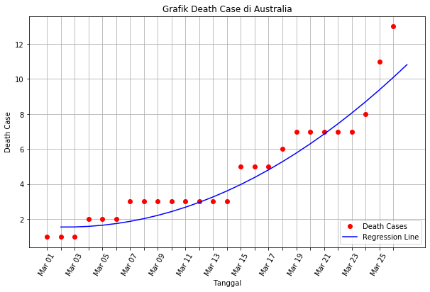

```python
australia_dc_po = regresi_death_polinomial(australia, 'after', 'Feb 29')
```

### Analisis kurva-kurva regresi pada *Death Cases* di Australia

```python
analisis('Death', australia_dc_p, australia_dc_e, australia_dc_po)
```

```
=== Death Cases hingga 26 Maret 2020 ===

        -Persamaan Regresi-
        Regresi Berpangkat: y = 0.0012146203508963862(x^(2.4241807762991976))
        Regresi Eksponensial: y = 0.2934e^(0.0893x)
        Regresi Polinomial orde 3: y = 5.6691 + (-0.5028)x + (0.0153)x^2 + (-0.0000)x^3

        -Koefisien Korelasi-
        Regresi Berpangkat: 0.9550
        Regresi Eksponensial: 0.9685
        Regresi Polinomial orde 3: 0.9624
```

```python
kurva_negara['australia']['dc'] = australia_dc_po
```

## 8. Amerika Serikat

```python
amerika = get_data('us', 'Amerika')
```

### Active Cases

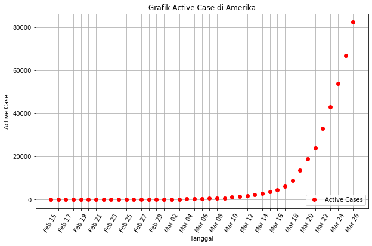

```python
plot_active_data(amerika)
```

### Persamaan Regresi Berpangkat untuk *Active Case* di Amerika

```
=== Persamaan Regresi Berpangkat pada Active Cases di Amerika ===
        Persamaan Regresi = y = 0.20166218583220522(x^(2.782845110701927))
        Koefisien Korelasi = 0.1050646459886422
```

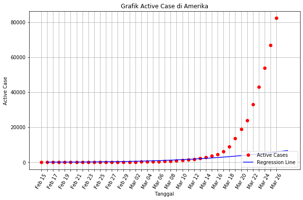

```python
amerika_ac_p = regresi_aktif_berpangkat(amerika)
```

### Persamaan Regresi Eksponensial untuk *Active Cases* di Amerika

```
=== Persamaan Regresi Eksponensial pada Active Cases di Amerika ===
        Persamaan Regresi = y = 3.2136e^(0.2367x)
        Koefisien Korelasi = 0.9130459399688055
```

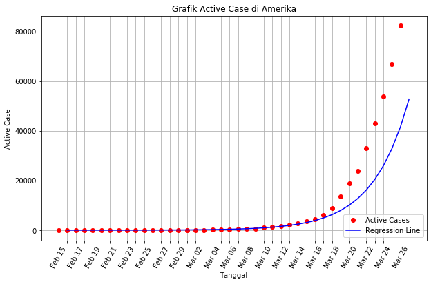

```python
amerika_ac_e = regresi_aktif_eksponensial(amerika)
```

### Persamaan Regresi Polinomial (orde 3) untuk *Active Cases* di Amerika

```
=== Persamaan Regresi Polinomial pada Active Cases di Amerika ===
        Persamaan Regresi = y = 10646.4097 + (-1963.2529)x + (46.2745)x^2 + (0.7026)x^3
        Koefisien Korelasi = 0.9156458330892576
```

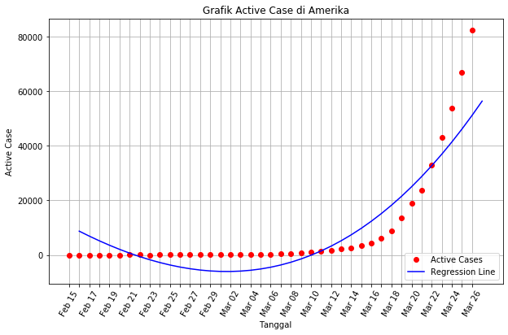

```python
amerika_ac_po = regresi_aktif_polinomial(amerika)
```

### Analisis kurva-kurva regresi pada *Active Cases* di Amerika

```python
analisis('Active', amerika_ac_p, amerika_ac_e, amerika_ac_po)
```

```
=== Active Cases hingga 26 Maret 2020 ===

        -Persamaan Regresi-
        Regresi Berpangkat: y = 0.20166218583220522(x^(2.782845110701927))
        Regresi Eksponensial: y = 3.2136e^(0.2367x)
        Regresi Polinomial orde 3: y = 10646.4097 + (-1963.2529)x + (46.2745)x^2 + (0.7026)x^3

        -Koefisien Korelasi-
        Regresi Berpangkat: 0.1051
        Regresi Eksponensial: 0.9130
        Regresi Polinomial orde 3: 0.9156
```

Dapat diambil kesimpulan dari data diatas, bahwa kurva regresi polinomial orde 3 dapat mewakili data *Active Cases* di Amerika.

```python
kurva_negara['amerika'] = {}
kurva_negara['amerika']['ac'] = amerika_ac_po
```

### Death Cases

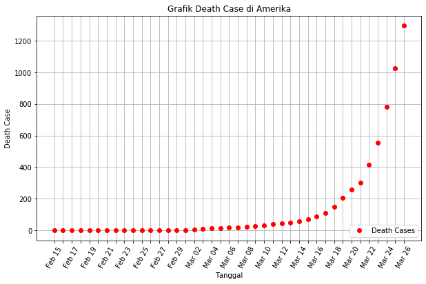

```python
plot_death_data(amerika)
```

```python
print(amerika['death_cases']['y'][0:15])
print(amerika['death_cases']['x'][14])
```

```
[0 0 0 0 0 0 0 0 0 0 0 0 0 0 1]
Feb 29
```

Terlihat bahwa sebelum tanggal 29 Februari, belum ada *Death Case* di Amerika. Maka, data yang saya gunakan untuk mencari persamaan regresi adalah data setelah 28 Februari.

### Persamaan Regresi Berpangkat untuk *Death Cases* di Amerika

```
=== Persamaan Regresi Berpangkat pada death Cases setelah Feb 28 di Amerika ===
            Persamaan Regresi = y = 7.903331255597202e-08(x^(6.181398132330291))
            Koefisien Korelasi = 0.901680693548565
```

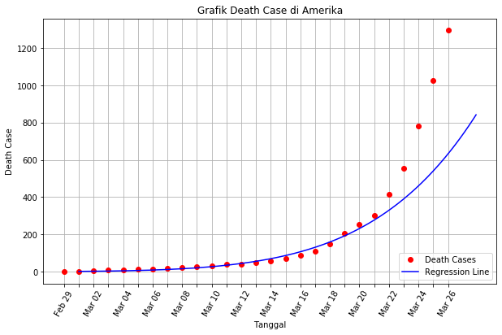

```python
amerika_dc_p = regresi_death_berpangkat(amerika, 'after', 'Feb 28')
```

### Persamaan Regresi Eksponensial untuk *Death Cases* di Amerika

```
=== Persamaan Regresi Eksponensial pada Death Cases setelah Feb 28 di Amerika ===
            Persamaan Regresi = y = 0.0762e^(0.2343x)
            Koefisien Korelasi = 0.9905145918910959
```

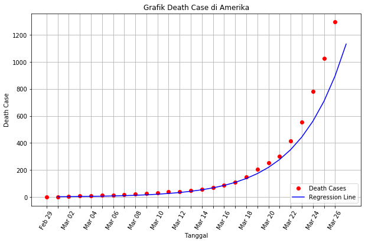

```python
amerika_dc_e = regresi_death_eksponensial(amerika, 'after', 'Feb 28')
```

### Persamaan Regresi Polinomial (orde 3) untuk *Death Cases* di Amerika

```
=== Persamaan Regresi Polinomial pada Death Cases setelah Feb 28 di Amerika ===
            Persamaan Regresi = y = 1708.4229 + (-154.1133)x + (3.3321)x^2 + (-0.0000)x^3
            Koefisien Korelasi = 0.9429380365547506
```

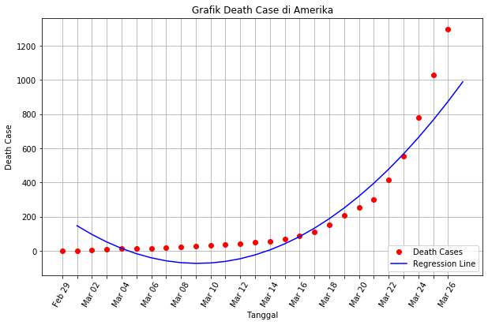

```python
amerika_dc_po = regresi_death_polinomial(amerika, 'after', 'Feb 28')
```

### Analisis kurva-kurva regrasi pada *Death Cases* di Amerika

```python
analisis('Death', amerika_dc_p, amerika_dc_e, amerika_dc_po)
```

```
=== Death Cases hingga 26 Maret 2020 ===

        -Persamaan Regresi-
        Regresi Berpangkat: y = 7.903331255597202e-08(x^(6.181398132330291))
        Regresi Eksponensial: y = 0.0762e^(0.2343x)
        Regresi Polinomial orde 3: y = 1708.4229 + (-154.1133)x + (3.3321)x^2 + (-0.0000)x^3

        -Koefisien Korelasi-
        Regresi Berpangkat: 0.9017
        Regresi Eksponensial: 0.9905
        Regresi Polinomial orde 3: 0.9429
```

Dari data di atas, dapat diambil kesimpulan bahwa yang dapat mewakili data *Death Cases* di Amerika merupakan kurva eksponensial.

```python
kurva_negara['amerika']['dc'] = amerika_dc_e
```

## 8. Indonesia

```python
indonesia = get_data('indonesia', 'Indonesia')
```

### Active Cases

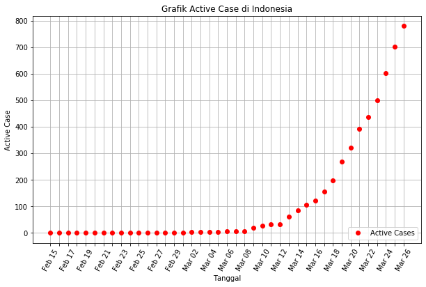

```python
plot_active_data(indonesia)
```

```python
print(indonesia['active_cases']['y'][0:17])
print(indonesia['active_cases']['x'][16])
```

```
[0 0 0 0 0 0 0 0 0 0 0 0 0 0 0 0 2]
Mar 02
```

### Persamaan Regresi Berpangkat untuk *Active Cases* di Indonesia

```
=== Persamaan Regresi Berpangkat pada Active Cases setelah Mar 02 di Indonesia ===
            Persamaan Regresi = y = 8.802179228336225e-11(x^(8.107008740843112))
            Koefisien Korelasi = 0.9571521517760067
```

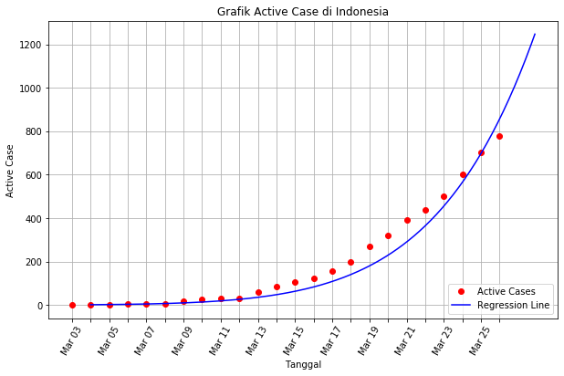

```python
indonesia_ac_p = regresi_aktif_berpangkat(indonesia, 'after', 'Mar 02')
```

### Persamaan Regresi Eksponensial untuk *Active Cases* di Indonesia

```
=== Persamaan Regresi Eksponensial pada Active Cases setelah Mar 02 di Indonesia ===
            Persamaan Regresi = y = 0.0135e^(0.2832x)
            Koefisien Korelasi = 0.6538507808412487
```

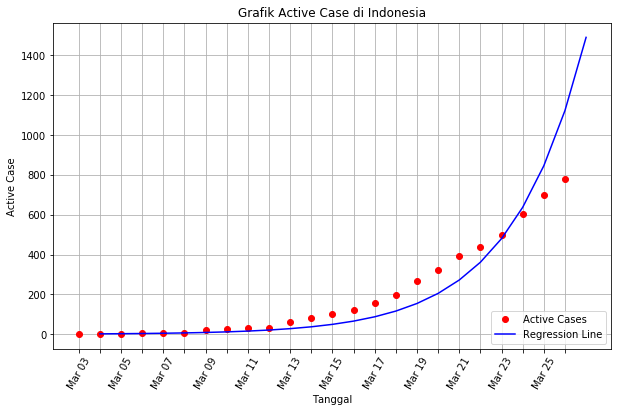

```python
indonesia_ac_e = regresi_aktif_eksponensial(indonesia, 'after', 'Mar 02')
```

### Persamaan Regresi Polinomial (orde 3) untuk *Active Cases* di Indonesia

```
=== Persamaan Regresi Polinomial pada Active Cases setelah Mar 02 di Indonesia ===
            Persamaan Regresi = y = 1195.0481 + (-105.9196)x + (2.3216)x^2 + (-0.0000)x^3
            Koefisien Korelasi = 0.9965529089111412
```

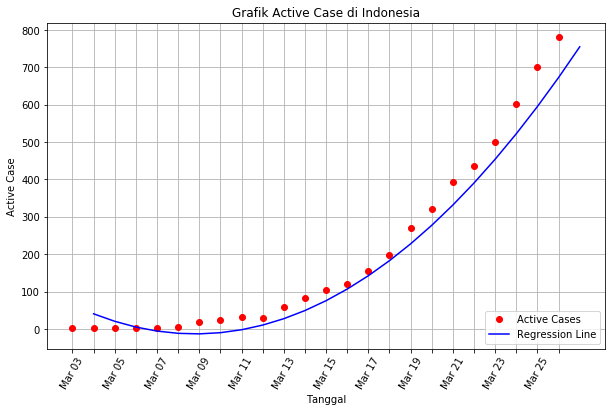

```python
indonesia_ac_po = regresi_aktif_polinomial(indonesia, 'after', 'Mar 02')
```

### Analisis kurva-kurva regresi pada *Active Cases* di Indonesia

```python
analisis('Active', indonesia_ac_p, indonesia_ac_e, indonesia_ac_po)
```

```
=== Active Cases hingga 26 Maret 2020 ===

        -Persamaan Regresi-
        Regresi Berpangkat: y = 8.802179228336225e-11(x^(8.107008740843112))
        Regresi Eksponensial: y = 0.0135e^(0.2832x)
        Regresi Polinomial orde 3: y = 1195.0481 + (-105.9196)x + (2.3216)x^2 + (-0.0000)x^3

        -Koefisien Korelasi-
        Regresi Berpangkat: 0.9572
        Regresi Eksponensial: 0.6539
        Regresi Polinomial orde 3: 0.9966
```

Dapat terlihat dari data di atas, bahwa kurva yang mewakili data *Active Cases* di Indonesia adalah kurva regresi polinomial orde 3.

```python
kurva_negara['indonesia'] = {}
kurva_negara['indonesia']['ac'] = indonesia_ac_po
```